# Trabajo final de Estadística Computacional

Pedro Alumbreros Menchén, Elena Merelo Molina, Iván Salido Cobo y Rubén Vílchez Valenzuela

2022-06-28

# Análisis del texto de distintas obras de prosa, poesía y teatro del Siglo de Oro español

El objetivo es analizar las principales diferencias entre las obras más famosas de prosa, poesía y teatro escritas en España durante el siglo XVII.

Las obras escogidas son:

- **Prosa:**
  - El ingenioso hidalgo Don Quijote de la Mancha *(Miguel de Cervantes)*
  - El ingenioso caballero Don Quijote de la Mancha *(Miguel de Cervantes)*
- **Poesía:**
  - El Parnaso Español *(Francisco Gómez de Quevedo)*
  - Soledades *(Luis de Góngora)*
- **Teatro:**
  - La vida es sueño *(Pedro Calderón de la Barca)*
  - El perro del hortelano *(Félix Lope de Vega)*

Además, se utilizará un pequeño repertorio de poemas de Quevedo para mostrar el uso de los paquetes.

## Paquetes utilizados

Como las obras están en PDF, se hará uso del paquete `pdftools` para extraer el texto.

Después, se usarán los paquetes `tokenizers` y `stopwords` para descomponer el texto y filtrar ciertas palabras.

Por último, se analizarán los datos resultantes con `tidyverse`, una librería que incluye varios paquetess.

```r
options(max.print = 20) # Para evitar que se impriman los libros enteros.
library(pdftools)
library(tokenizers)
library(stopwords)
library(tidyverse)
```

## Leyendo los PDFs

El paguete `pdftools` permite leer el texto de un PDF con la función `pdf_text`. Se continúa leyendo el texto de todos los PDFs utilizando `lapply`. Por último, se almacenan los poemas de prueba.

```r
pdfs <- list.files(pattern = "pdf$")
libros <- lapply(pdfs, pdf_text)
poemas_prueba <- read_file("poemas-prueba.txt")
```

Donde `libros` es una lista con los PDFs. Cada elemento de la lista *(cada libro)* es un vector con tantos elementos como páginas tenga el PDF y en cada elemento el texto que haya en esa página del PDF.

Esto, sin embargo, es un inconveniente, ya que para analizar correctamente cada libro, no debería estar el texto separado por páginas, sino todo junto. Para solucionarlo, añadiremos los datos a un *data frame* y juntaremos el texto de todas las páginas.

```r
libros <- data.frame(matrix(ncol = 4, nrow = 0))
colnames(libros) <- c("titulo", "autor", "texto", "n_palabras")
for (pdf in pdfs) {
  info <- pdf_info(pdf)
  libros[nrow(libros) + 1,] <- c(info$keys$Title, info$keys$Author, str_c(pdf_text(pdf), collapse = ""), NA)
}

cat(strtrim(libros$texto[1], 950)) # Mostramos solo una parte de la obra.
```

```
##                                    -V-
## A la estatua de bronce del Santo Rey Don Felipe III, que está en la casa
##                del campo de Madrid, traída de Florencia
##
##
##                 ¡Oh cuánta majestad! ¡Oh cuánto numen,
##                    en el tercer Filipo, invicto y santo,
##                presume el bronce que le imita! ¡Oh cuánto
##                   estos semblantes en su luz presumen!
##                   Los siglos reverencian, no consumen,
##                    bulto que igual adoración y espanto
##                    mereció amigo y enemigo, en tanto
##                     que de su vida dilató el volumen.
##                        Osó imitar artífice toscano
##                    al que a Dios imitó de tal manera,
##                   que es, por rey y por santo, soberano.
##                   El bronce, por su imagen verdadera,
##                   se introduce en reliquia, y éste, llano,
##                      en majestad augusta reverbera.
##
##
##
##
```

## Preparando los datos

Ahora es necesario *tokenizar* el texto leído.

El proceso de *tokenización* consiste en descomponer una cadena de texto en *tokens*, esto es, elementos más pequeños computables. Un ejemplo sería la descomposición del texto en palabras o en letras. Por otro lado, se usarán herramientas para procesar textos en distintos formatos con el fin de facilitar su manipulación.

Con la función `tokenize_words` se extraen y se almacenan las palabras.

```r
tokenize_words(poemas_prueba)
```

```
## [[1]]
##  [1] "a"           "un"          "hombre"      "de"          "gran"
##  [6] "nariz"       "érase"       "un"          "hombre"      "a"
## [11] "una"         "nariz"       "pegado"      "érase"       "una"
## [16] "nariz"       "superlativa" "érase"       "una"         "alquitara"
##  [ reached getOption("max.print") -- omitted 843 entries ]
```

A la hora de extraer las palabras, podemos además especificar un vector de palabras vacías *(palabras que no tienen un significado por sí solas, como pueden ser artículos, pronombres, preposiciones, adverbios, …)*, que se omitirán. Para esto es útil el paquete `stopwords`, que contiene las palabras vacías o *stopwords* para distintos idiomas. El idioma se especifica como argumento en forma de su código ISO 639-1, por ejemplo, para el español, se usa el código `"es"`. Un ejemplo donde extraemos las palabras de un libro especificando palabras vacías del español con ayuda del paquete `stopwords`:

```r
tokenize_words(poemas_prueba, stopwords = stopwords::stopwords("es"))
```

```
## [[1]]
##  [1] "hombre"      "gran"        "nariz"       "érase"       "hombre"
##  [6] "nariz"       "pegado"      "érase"       "nariz"       "superlativa"
## [11] "érase"       "alquitara"   "medio"       "viva"        "érase"
## [16] "peje"        "espada"      "mal"         "barbado"     "reloj"
##  [ reached getOption("max.print") -- omitted 440 entries ]
```

Otra opción a la hora de analizar las palabras de un texto es tomar las raíces de las palabras en lugar de las palabras completas, lo cual da pie a más formas de estudiar un texto desde el punto de vista lingüístico. Esto se puede conseguir con ayuda de la función `tokenize_word_stems`:

```r
tokenize_word_stems(poemas_prueba, language = "spanish")
```

```
## [[1]]
##  [1] "a"      "un"     "hombr"  "de"     "gran"   "nariz"  "eras"   "un"
##  [9] "hombr"  "a"      "una"    "nariz"  "peg"    "eras"   "una"    "nariz"
## [17] "superl" "eras"   "una"    "alquit"
##  [ reached getOption("max.print") -- omitted 843 entries ]
```

No solo nos quedamos en las palabras, si no que además podemos tomar el texto y separarlo en todas las letras que lo componen, que son los menores *tokens* que podremos encontrar.

```r
tokenize_characters(poemas_prueba)
```

```
## [[1]]
##  [1] "a" "u" "n" "h" "o" "m" "b" "r" "e" "d" "e" "g" "r" "a" "n" "n" "a" "r" "i"
## [20] "z"
##  [ reached getOption("max.print") -- omitted 3677 entries ]
```

En el paquete encontramos otra función que permite dividir el texto en partes más pequeñas de igual longitud.

```r
chunk_text(poemas_prueba, chunk_size = 80)
```

```
## [[1]]
## [1] "a un hombre de gran nariz érase un hombre a una nariz pegado érase una nariz superlativa érase una alquitara medio viva érase un peje espada mal barbado era un reloj de sol mal encarado érase un elefante boca arriba érase una nariz sayón y escriba un ovidio nasón mal narigado érase el espoló…
##
## [[2]]
## [1] "a una dama bizca y hermosa si a una parte miraran solamente vuestros ojos cuál parte no abrasaran y si a diversas partes no miraran se helaran el ocaso o el oriente el mirar zambo y zurdo es delincuente vuestras luces izquierdas lo declaran pues con mira engañosa nos disparan facinorosa luz …
##
## [[3]]
## [1] "mover pudo al mal jurista a que siendo monarcas los dos ojos los llamase vizcondes de la vista definición del amor es hielo abrasador es fuego helado es herida que duele y no se siente es un soñado bien un mal presente es un breve descanso muy cansado es un descuido que nos da cuidado un cob…
##
## [[4]]
## [1] "postrero paroxismo enfermedad que crece si es curada éste es el niño amor éste es su abismo mirad cuál amistad tendrá con nada el que en todo es contrario de sí mismo romance satírico pues me hacéis casamentero ángela de mondragón escuchad de vuestro esposo las grandezas y el valor él es un …
##
## [[5]]
## [1] "mintió que ha muerto más hombres vivos que mató el cid campeador en entrando en una casa tiene tal reputación que luego dicen los niños dios perdone al que murió y con ser todos mortales los médicos pienso yo que son todos venïales comparados al dotor al caminante en los pueblos se le pide i…
##
## [[6]]
## [1] "a su escuadrón si a alguno cura y no muere piensa que resucitó y por milagro le ofrece la mortaja y el cordón si acaso estando en su casa oye dar algún clamor tomando papel y tinta escribe ante mí pasó no se le ha muerto ninguno de los que cura hasta hoy porque antes que se mueran los mata s…
##
## [[7]]
## [1] "que es la muerte algunos otros viendo su rigor le llaman el día del juicio pues es total perdición no come por engordar ni por el dulce sabor sino por matar la hambre que es matar su inclinación por matar mata las luces y si no le alumbra el sol como murciégalo vive a la sombra de un rincón …
##
## [[8]]
## [1] "peor él que se ve tan famoso y en tan buena estimación atento a vuestra belleza se ha enamorado de vos no pide le deis más dote de ver que matáis de amor que en matando de algún modo para en uno sois los dos casaos con él y jamás vïuda tendréis pasión que nunca la misma muerte se oyó decir q…
##
## [[9]]
## [1] "libre de conocer al dotor poderoso caballero es don dinero madre yo al oro me humillo él es mi amante y mi amado pues de puro enamorado anda continuo amarillo que pues doblón o sencillo hace todo cuanto quiero poderoso caballero es don dinero nace en las indias honrado donde el mundo le acom…
##
## [[10]]
## [1] "dinero son sus padres principales y es de nobles descendiente porque en las venas de oriente todas las sangres son reales y pues es quien hace iguales al rico y al pordiosero poderoso caballero es don dinero a quién no le maravilla ver en su gloria sin tasa que es lo más ruin de su casa doña…
##
## [[11]]
## [1] "aunque son sus duelos hartos que aun con estar hecho cuartos no pierde su calidad pero pues da autoridad al gañán y al jornalero poderoso caballero es don dinero más valen en cualquier tierra mirad si es harto sagaz sus escudos en la paz que rodelas en la guerra pues al natural destierra y h…
```

También se pueden separar párrafos y frases con las funciones `tokenize_sentences` y `tokenize_paragraphs` respectivamente. Vemos un ejemplo de separación de frases.

```r
tokenize_sentences(poemas_prueba)
```

```
## [[1]]
##  [1] "A un hombre de gran nariz  Érase un hombre a una nariz pegado, Érase una nariz superlativa, Érase una alquitara medio viva, Érase un peje espada mal barbado;  Era un reloj de sol mal encarado."
##  [2] "Érase un elefante boca arriba, Érase una nariz sayón y escriba, Un Ovidio Nasón mal narigado."
##  [3] "Érase el espolón de una galera, Érase una pirámide de Egito, Los doce tribus de narices era;  Érase un naricísimo infinito, Frisón archinariz, caratulera, Sabañón garrafal morado y frito."
##  [4] "A una dama bizca y hermosa  Si a una parte miraran solamente vuestros ojos, ¿cuál parte no abrasaran?"
##  [5] "Y si a diversas partes no miraran, se helaran el ocaso o el Oriente."
##  [6] "El mirar zambo y zurdo es delincuente; vuestras luces izquierdas lo declaran, pues con mira engañosa nos disparan facinorosa luz, dulce y ardiente."
##  [7] "Lo que no miran ven, y son despojos suyos cuantos los ven, y su conquista da a l’alma tantos premios como enojos."
##  [8] "¿Qué ley, pues, mover pudo al mal jurista a que, siendo monarcas los dos ojos, los llamase vizcondes de la vista?"
##  [9] "Definición del amor  Es hielo abrasador, es fuego helado, es herida que duele y no se siente, es un soñado bien, un mal presente, es un breve descanso muy cansado."
## [10] "Es un descuido que nos da cuidado, un cobarde con nombre de valiente, un andar solitario entre la gente, un amar solamente ser amado."
## [11] "Es una libertad encarcelada, que dura hasta el postrero paroxismo; enfermedad que crece si es curada."
## [12] "Éste es el niño Amor, éste es su abismo."
## [13] "¿Mirad cuál amistad tendrá con nada el que en todo es contrario de sí mismo!"
## [14] "Romance satírico  Pues me hacéis casamentero, Ángela de Mondragón, escuchad de vuestro esposo las grandezas y el valor."
## [15] "Él es un Médico honrado, por la gracia del Señor, que tiene muy buenas letras en el cambio y el bolsón."
## [16] "Quien os lo pintó cobarde no lo conoce, y mintió, que ha muerto más hombres vivos que mató el Cid Campeador."
## [17] "En entrando en una casa tiene tal reputación, que luego dicen los niños: «Dios perdone al que murió»."
## [18] "Y con ser todos mortales los Médicos, pienso yo que son todos venïales, comparados al Dotor."
## [19] "Al caminante, en los pueblos se le pide información, temiéndole más que a la peste de si le conoce, o no."
## [20] "De Médicos semejantes hace el Rey nuestro Señor bombardas a sus castillos, mosquetes a su escuadrón."
##  [ reached getOption("max.print") -- omitted 24 entries ]
```

Además se pueden contar letras, palabras o frases de un texto con las funciones `count_words`, `count_characters` y `count_sentences` respectivamente. Aunque es posible *tokenizar* el texto con las funciones ya vistas y computar la longitud de los vectores obtenidos, estas funciones nos ofrecen un recuento de forma directa si no queremos dar pasos intermedios.

```r
count_words(poemas_prueba)
```

```
## [1] 863
```

Otra opción a la hora de *tokenizar* el texto, igual que tomar frases, palabras, o párrafos, es tomar *n-gramas*: subsecuencias de a lo sumo *n* elementos contiguos de una secuencia dada, y como mínimo *n_min* elementos. En este caso es también posible utilizar la opción de excluir palabras vacías si se desea. Veamos un ejemplo donde tomamos *n-gramas* de entre *1* y *6* palabras:

```r
tokenize_ngrams(poemas_prueba, n = 6, n_min = 1)
```

```
## [[1]]
##  [1] "a"                             "a un"
##  [3] "a un hombre"                   "a un hombre de"
##  [5] "a un hombre de gran"           "a un hombre de gran nariz"
##  [7] "un"                            "un hombre"
##  [9] "un hombre de"                  "un hombre de gran"
## [11] "un hombre de gran nariz"       "un hombre de gran nariz érase"
## [13] "hombre"                        "hombre de"
## [15] "hombre de gran"                "hombre de gran nariz"
## [17] "hombre de gran nariz érase"    "hombre de gran nariz érase un"
## [19] "de"                            "de gran"
##  [ reached getOption("max.print") -- omitted 5143 entries ]
```

Veamos el mismo caso omitiendo palabras vacías:

```r
tokenize_ngrams(poemas_prueba, n = 6, n_min = 1, stopwords = stopwords::stopwords("es"))
```

```
## [[1]]
##  [1] "hombre"
##  [2] "hombre gran"
##  [3] "hombre gran nariz"
##  [4] "hombre gran nariz érase"
##  [5] "hombre gran nariz érase hombre"
##  [6] "hombre gran nariz érase hombre nariz"
##  [7] "gran"
##  [8] "gran nariz"
##  [9] "gran nariz érase"
## [10] "gran nariz érase hombre"
## [11] "gran nariz érase hombre nariz"
## [12] "gran nariz érase hombre nariz pegado"
## [13] "nariz"
## [14] "nariz érase"
## [15] "nariz érase hombre"
## [16] "nariz érase hombre nariz"
## [17] "nariz érase hombre nariz pegado"
## [18] "nariz érase hombre nariz pegado érase"
## [19] "érase"
## [20] "érase hombre"
##  [ reached getOption("max.print") -- omitted 2725 entries ]
```

A raíz de esto surge también la opción de tomar *n-gramas* con *k-saltos*: como su propio nombre indica, hace lo mismo que el proceso de tomar *n-gramas*, pero con la opción de omitir entre *0* y *k* palabras en el *n-grama*, en lugar de tomar subsecuencias con todas las palabras contiguas. De nuevo, es posible incluir una lista de palabras vacías que evitar en el proceso.

```r
tokenize_skip_ngrams(poemas_prueba, n = 3, n_min = 1, k = 1)
```

```
## [[1]]
##  [1] "a"                 "a un"              "a hombre"
##  [4] "a un hombre"       "a un de"           "a hombre de"
##  [7] "a hombre gran"     "un"                "un hombre"
## [10] "un de"             "un hombre de"      "un hombre gran"
## [13] "un de gran"        "un de nariz"       "hombre"
## [16] "hombre de"         "hombre gran"       "hombre de gran"
## [19] "hombre de nariz"   "hombre gran nariz"
##  [ reached getOption("max.print") -- omitted 6006 entries ]
```

```r
tokenize_skip_ngrams(poemas_prueba, n = 3, n_min = 1, k = 1, stopwords = stopwords::stopwords("es"))
```

```
## [[1]]
##  [1] "hombre"              "hombre gran"         "hombre nariz"
##  [4] "hombre gran nariz"   "hombre gran érase"   "hombre nariz érase"
##  [7] "hombre nariz hombre" "gran"                "gran nariz"
## [10] "gran érase"          "gran nariz érase"    "gran nariz hombre"
## [13] "gran érase hombre"   "gran érase nariz"    "nariz"
## [16] "nariz érase"         "nariz hombre"        "nariz érase hombre"
## [19] "nariz érase nariz"   "nariz hombre nariz"
##  [ reached getOption("max.print") -- omitted 3185 entries ]
```

Para el este estudio, se usarán como *tokens* todas las palabras eliminando las palabras vacías. Además, se eliminarán también los nombres de los personajes de las obras y algunas palabras más, que se han colocado en un documento de texto.

Después de *tokenizar* el texto, se guardará también la cantidad de palabras que quedan.

Una cosa a tener en cuenta es que `tokenize_words` devuelve una lista con las palabras por documento *tokenizado*. Como solo estamos *tokenizando* un único texto cada vez que usamos la función, hay que poner `[[1]]` para sacar el texto de la lista.

```r
palabras_extra <- tokenize_words(read_file("palabras_extra.txt"))[[1]]

for (i in 1:nrow(libros)) {
  libros[i, "texto"] <- str_c(tokenize_words(libros[i, "texto"], stopwords = c(stopwords::stopwords("es"), palabras_extra))[[1]], collapse = " ")
  libros[i, "n_palabras"] <- count_words(libros[i, "texto"])
}
```

Lo que hemos hecho es juntar todos los *tokens* en un solo *string* separados por espacios.

Para poder analizar la obras con mayor comodidad, vamos a separar cada *token* en una fila del *data frame*. La función `separate_rows` nos permite sacar todos los *tokens* separados por espacios a una fila individual.

```r
libros_separados <- separate_rows(libros, texto, sep = "[[:space:]]")
head(libros_separados)
```

```
## # A tibble: 6 × 4
##   titulo          autor                texto   n_palabras
##   <chr>           <chr>                <chr>   <chr>
## 1 Parnaso Español Francisco de Quevedo v       18238
## 2 Parnaso Español Francisco de Quevedo estatua 18238
## 3 Parnaso Español Francisco de Quevedo bronce  18238
## 4 Parnaso Español Francisco de Quevedo santo   18238
## 5 Parnaso Español Francisco de Quevedo rey     18238
## 6 Parnaso Español Francisco de Quevedo felipe  18238
```

Lo que nos ha devuelto `head(libros)` es las primeras filas. Observamos que `libros` ya no es un *data frame*, sino un objeto llamado `tibble`, esto es una alternativa al *data frame* con la que trabajan los paquetes de `tidyverse`. La función `separate_rows` ha convertido automáticamente el *data frame* a `tibble`.

## Analizando los datos

Pasamos a ver qué palabras se repiten más en los textos. Aquí vamos a utilizar el operador `%>%`, que le pasa la parte de la izquierda a la función de la derecha como primer parámetro.

```r
palabras_repetidas <- libros_separados %>%
  count(texto, sort = TRUE)

palabras_repetidas
```

```
## # A tibble: 28,166 × 2
##    texto         n
##    <chr>     <int>
##  1 si         3558
##  2 dijo       2817
##  3 tan        1930
##  4 señor      1803
##  5 ser        1787
##  6 bien       1770
##  7 pues       1734
##  8 respondió  1693
##  9 así        1691
## 10 merced     1428
## # … with 28,156 more rows
```

Para mostrar los datos en un gráfico, utilizaremos la función `ggplot`. A esa función hay que proporcionarle los datos a mostrar. Pedirle que muestre todas las palabras sería una locura, así que se mostrarán solo unas pocas.

Usamos `slice_head` para *“cortar”* una porción de los datos de cada grupo. En este caso, sólo las primeras filas, que son las que tienen las palabras más frecuentes:

La función `ggplot` recibe también el tipo de gráfico, que será `geom_bar`, es decir, un gráfico de barras. `aes` indica la variable que se utilizará para el gráfico.

Por último `coord_flip` invierte las coordenadas para que las barras sean horizontales y `labs` genera la leyenda.

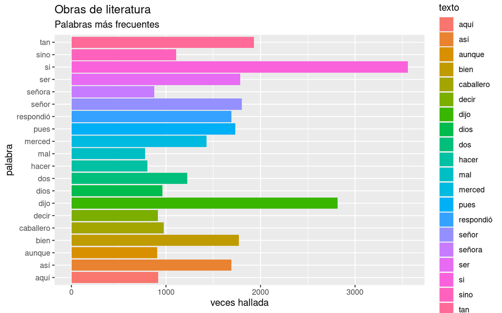

```r
palabras_repetidas %>%
  slice_head(n = 20) %>%
  ggplot() +
  geom_bar(aes(x = texto, weight = n, fill = texto)) +
  coord_flip() +
  labs(title = "Obras de literatura",
       subtitle = "Palabras más frecuentes",
       x = "palabra",
       y = "veces hallada")
```

Visualizemos las palabras más frecuente por título.

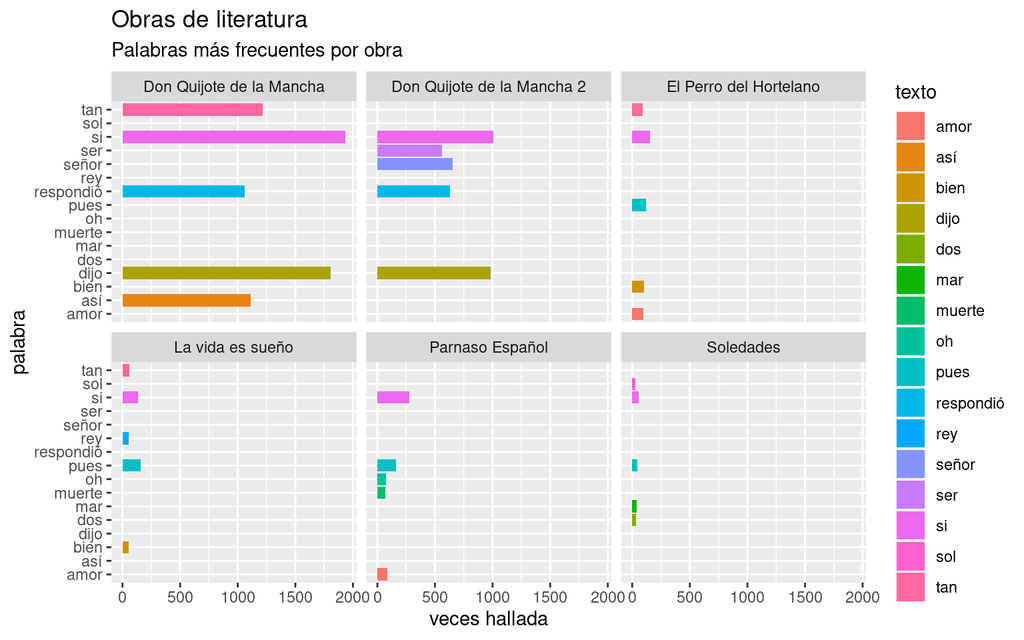

```r
libros_separados %>%
  group_by(titulo) %>%
  count(texto, sort = TRUE) %>%
  slice_head(n = 5) %>%
  ggplot() +
  geom_bar(aes(x = texto, weight = n, fill = texto)) +
  coord_flip() +
  facet_wrap(~titulo) +
  labs(title = "Obras de literatura",
     subtitle = "Palabras más frecuentes por obra",
     x = "palabra",
     y = "veces hallada")
```

Inmediatamente nos damos cuenta de un problema, en las obras del Quijote hay muchas más repeticiones porque la obra es más extensa, no necesariamente porque se repitan más veces esas palabras.

Para solucionarlo, podemos intentar ver en qué proporción se repiten esas palabras con respecto al total de palabras que tiene el libro.

La función `count` nos permite indicar unos pesos para cada observación, estos pesos serán `1 / n_palabras`, lo que nos dará la proporción de veces que aparece la palabra con el total de palabras que tiene la obra.

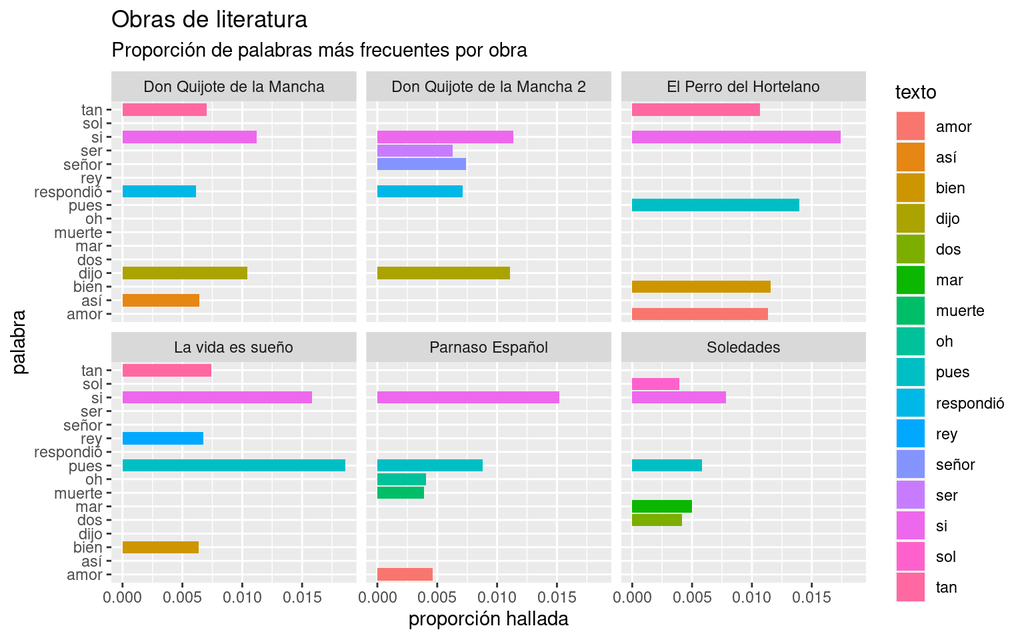

```r
libros_separados %>%
  group_by(titulo) %>%
  count(texto, sort = TRUE, wt = 1 / as.numeric(n_palabras)) %>%
  slice_head(n = 5) %>%
  ggplot() +
  geom_bar(aes(x = texto, weight = n, fill = texto)) +
  coord_flip() +
  facet_wrap(~titulo) +
  labs(title = "Obras de literatura",
       subtitle = "Proporción de palabras más frecuentes por obra",
       x = "palabra",
       y = "proporción hallada")
```

Vovemos a fijarnos en algo extraño, y es que no parece que se hayan contado las palabras bien en algunas obras. Por ejemplo, la gráfica nos dice que en ninguno de los libros del Quijote aparece la palabra *“sol”*, esto no tiene sentido, pues si buscamos manualmente en el documento veremos que sí aparece.

Para entender el problema hay que analizar los datos que le estamos pasando a la gráfica para mostrar.

```r
libros_separados %>%
  group_by(titulo) %>%
  count(texto, sort = TRUE)
```

```
## # A tibble: 55,411 × 3
## # Groups:   titulo [6]
##    titulo                     texto         n
##    <chr>                      <chr>     <int>
##  1 Don Quijote de la Mancha   si         1934
##  2 Don Quijote de la Mancha   dijo       1805
##  3 Don Quijote de la Mancha   tan        1219
##  4 Don Quijote de la Mancha   así        1114
##  5 Don Quijote de la Mancha   respondió  1061
##  6 Don Quijote de la Mancha   ser        1056
##  7 Don Quijote de la Mancha   señor      1049
##  8 Don Quijote de la Mancha   bien       1040
##  9 Don Quijote de la Mancha 2 si         1005
## 10 Don Quijote de la Mancha 2 dijo        983
## # … with 55,401 more rows
```

Comparamos la diferencia de contar las palabras habiendo agrupado por título y sin haberlo hecho *(que tenemos un poco más arriba en la variable `palabras repetidas`)*.

Entonces, lo que hace `group_by` es que las palabras se cuenten por libro, no en general.

Veamos nuevamente cómo quedan ordeandas las palabras con los pesos, ya que nos interesa ver qué palabra aparece más en proporción, no simplemente porque haya obras más largas que otras.

```r
libros_separados %>%
  count(texto, sort = TRUE, wt = 1 / as.numeric(n_palabras))
```

```
## # A tibble: 28,166 × 2
##    texto       n
##    <chr>   <dbl>
##  1 si     0.0788
##  2 pues   0.0566
##  3 bien   0.0357
##  4 tan    0.0356
##  5 ser    0.0284
##  6 dos    0.0253
##  7 dijo   0.0249
##  8 señor  0.0239
##  9 aunque 0.0203
## 10 amor   0.0200
## # … with 28,156 more rows
```

Comparamos el resultado agrupando por título.

```r
libros_separados %>%
  group_by(titulo) %>%
  count(texto, sort = TRUE, wt = 1 / as.numeric(n_palabras))
```

```
## # A tibble: 55,411 × 3
## # Groups:   titulo [6]
##    titulo                     texto      n
##    <chr>                      <chr>  <dbl>
##  1 La vida es sueño           pues  0.0186
##  2 El Perro del Hortelano     si    0.0174
##  3 La vida es sueño           si    0.0159
##  4 Parnaso Español            si    0.0152
##  5 El Perro del Hortelano     pues  0.0140
##  6 El Perro del Hortelano     bien  0.0116
##  7 Don Quijote de la Mancha 2 si    0.0114
##  8 El Perro del Hortelano     amor  0.0113
##  9 Don Quijote de la Mancha   si    0.0112
## 10 Don Quijote de la Mancha 2 dijo  0.0111
## # … with 55,401 more rows
```

Vemos que, aplicando la proporción, no salen las mismas palabras que sin aplicarla. Nos queda comprobar qué hacen `slice` y `slice_head`.

```r
libros_separados %>%
  count(texto, sort = TRUE, wt = 1 / as.numeric(n_palabras)) %>%
  slice_head(n = 5) # `slice_head` necesita especificar `n = 5`, `slice` permite poner el número directamente.
```

```
## # A tibble: 5 × 2
##   texto      n
##   <chr>  <dbl>
## 1 si    0.0788
## 2 pues  0.0566
## 3 bien  0.0357
## 4 tan   0.0356
## 5 ser   0.0284
```

```r
libros_separados %>%
  count(texto, sort = TRUE, wt = 1 / as.numeric(n_palabras)) %>%
  slice(5)
```

```
## # A tibble: 1 × 2
##   texto      n
##   <chr>  <dbl>
## 1 ser   0.0284
```

Así que `slice_head` nos devuelve los primeros *n* elementos, mientas que `slice` nos devuelve el elemento en la posición `n`. Para ver las principales palabras más repetidas nos interesará utilizar `slice_head`.

Por último, veamos código completo que se le pasa a la gráfica.

```r
libros_separados %>%
  group_by(titulo) %>%
  count(texto, sort = TRUE, wt = 1 / as.numeric(n_palabras)) %>%
  slice_head(n = 5)
```

```
## # A tibble: 30 × 3
## # Groups:   titulo [6]
##    titulo                     texto           n
##    <chr>                      <chr>       <dbl>
##  1 Don Quijote de la Mancha   si        0.0112
##  2 Don Quijote de la Mancha   dijo      0.0104
##  3 Don Quijote de la Mancha   tan       0.00705
##  4 Don Quijote de la Mancha   así       0.00644
##  5 Don Quijote de la Mancha   respondió 0.00613
##  6 Don Quijote de la Mancha 2 si        0.0114
##  7 Don Quijote de la Mancha 2 dijo      0.0111
##  8 Don Quijote de la Mancha 2 señor     0.00740
##  9 Don Quijote de la Mancha 2 respondió 0.00713
## 10 Don Quijote de la Mancha 2 ser       0.00632
## # … with 20 more rows
```

Y ahí está el problema, `slice_head` nos devuelve las *5* primeras palabras más repetidas en cada libro. Como no siempre son las mismas en cada libro, hay gráficas en las que no aparece la cantidad de repeticiones de una palabra porque no está entre las *5* más repetidas de ese libro.

¿Cuál sería la solución? Primero hay que tener claro qué queremos mostrar. Queremos ver cuánto aparecen en cada libro las palabras más repetidas en general, es decir, buscar en cada libro las repeticiones de las *n* primeras palabras de `palabras_repetidas`:

```r
palabras_buscadas <- palabras_repetidas %>% slice_head(n = 10)
```

Vamos a intentar conseguir esas palabras en cada libro.

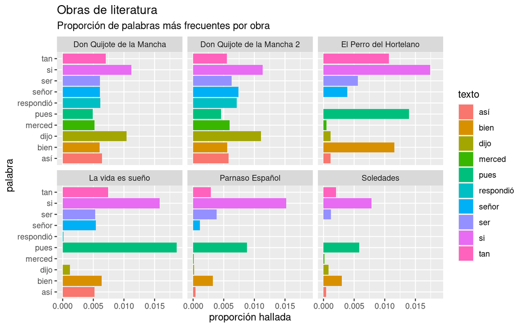

```r
libros_separados %>%
  group_by(titulo) %>%
  count(texto, sort = TRUE, wt = 1 / as.numeric(n_palabras)) %>%
  filter(texto %in% palabras_buscadas$texto) %>%
  ggplot() +
  geom_bar(aes(x = texto, weight = n, fill = texto)) +
  coord_flip() +
  facet_wrap(~titulo) +
  labs(title = "Obras de literatura",
       subtitle = "Proporción de palabras más frecuentes por obra",
       x = "palabra",
       y = "proporción hallada")
```

¡Y ahora sí que tienen mucho más sentido los resultados!

Aun así, las palabras que aparecen como más repetitivas no tienen mucho interés, vamos a probar a coger palabras que estén entre las más repetidas pero sean las primeras. Aquí si usaremos `slice`:

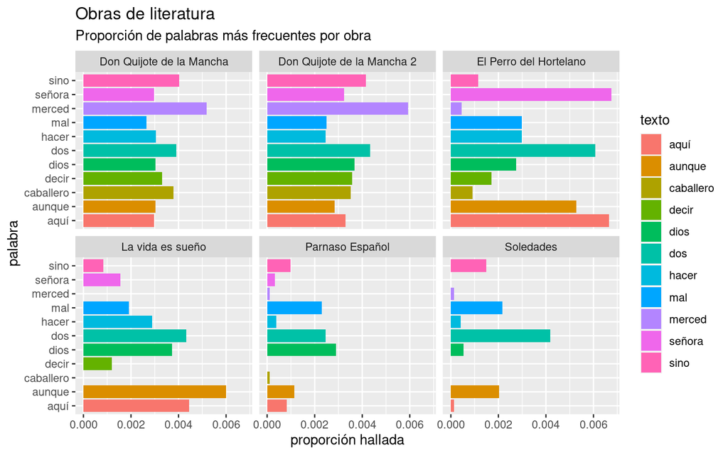

```r
palabras_buscadas <- palabras_repetidas %>% slice(10:20)

libros_separados %>%
  group_by(titulo) %>%
  count(texto, sort = TRUE, wt = 1 / as.numeric(n_palabras)) %>%
  filter(texto %in% palabras_buscadas$texto) %>%
  ggplot() +
  geom_bar(aes(x = texto, weight = n, fill = texto)) +
  coord_flip() +
  facet_wrap(~titulo) +
  labs(title = "Obras de literatura",
       subtitle = "Proporción de palabras más frecuentes por obra",
       x = "palabra",
       y = "proporción hallada")
```

Como curiosidad, podemos ver las palabras menos repetidas en vez de las más repetidas con `slice_tail`:

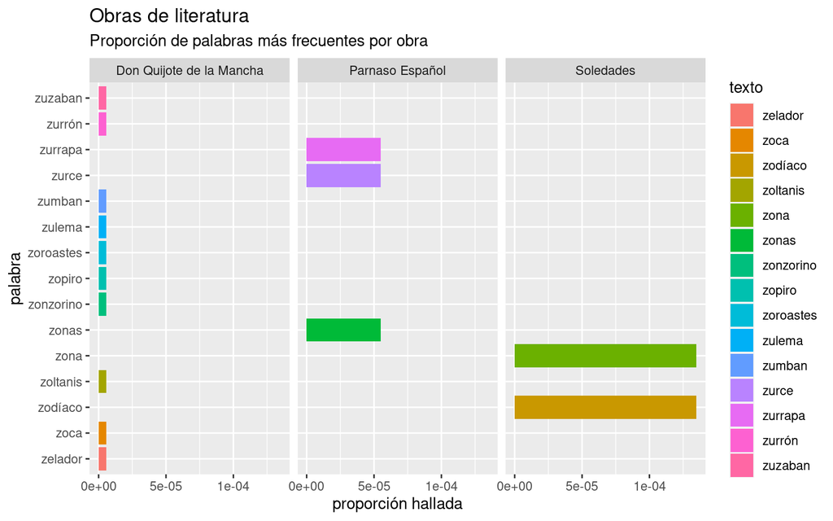

```r
palabras_buscadas <- palabras_repetidas %>% slice_tail(n = 15)

libros_separados %>%
  group_by(titulo) %>%
  count(texto, sort = TRUE, wt = 1 / as.numeric(n_palabras)) %>%
  filter(texto %in% palabras_buscadas$texto) %>%
  ggplot() +
  geom_bar(aes(x = texto, weight = n, fill = texto)) +
  coord_flip() +
  facet_wrap(~titulo) +
  labs(title = "Obras de literatura",
       subtitle = "Proporción de palabras más frecuentes por obra",
       x = "palabra",
       y = "proporción hallada")
```

Curiosamente, todas las palabras menos repetidas empiezan por *“z”*.